# Lake Turkana Isotope Hydrology: New measurements, evaporation model, and mass balance

2022-05-02

# To do

## Investigate temporal variability in precip

- Show ENSO years with time series
- Quantify time elapsed between precipitation events and lake water sample collection dates
- Is diurnal variability important (@Nicholson2022)

## Mass balance

- Estimate lake volumes from [USDA Foreign Agriculture Service](https://ipad.fas.usda.gov/cropexplorer/global_reservoir/gr_regional_chart.aspx?regionid=eafrica&reservoir_name=Turkana&lakeid=000093) and estimate percent increases in inputs needed.

## Test models

Set k = 0.1, equilibrium between precip and vapor above the lake is probably low because vapor isotope composition reflects evaporated lake water, not precip signal, Changing k has little effect on model slope.

Set TC = 30, close to mean of 11 measured surface temperatures and close to recorded MAAT. Temperature also has little effect on model slope.

- Regress lake only
- Is the best model the one that best fits the lake data?
- Define isotope mass balance equations and show solutions with measured and model predicted values
- Compare models with lake regression
- Quantify effect of each atmospheric variable on model — how?

# Data

## Table 1. New measurements

```
## # A tibble: 133 × 9
##    SampleID Date       Latitude Longitude Location WaterType  d18O    dD Dexcess
##    <chr>    <date>        <dbl>     <dbl> <chr>    <chr>     <dbl> <dbl>   <dbl>
##  1 R01      2017-01-29     4.29      36.3 TBI-Ile… Precipit… -0.56 -7.25   -2.77
##  2 R02      2017-01-30     4.29      36.3 TBI-Ile… Precipit…  1.45  5.21   -6.39
##  3 R03      2017-02-01     4.29      36.3 TBI-Ile… Precipit…  4.67 28.9    -8.46
##  4 R04      2017-02-04     4.29      36.3 TBI-Ile… Precipit…  5.93 20.5   -27.0
##  5 R06      2017-02-18     4.29      36.3 TBI-Ile… Precipit…  2.71 26.2     4.54
##  6 R07      2017-02-28     4.29      36.3 TBI-Ile… Precipit…  4.09 32.4    -0.33
##  7 R08      2017-05-28     4.29      36.3 TBI-Ile… Precipit…  2.94 24.9     1.34
##  8 R09      2017-05-30     4.29      36.3 TBI-Ile… Precipit… -0.18  5.01    6.45
##  9 R11      2017-07-04     4.29      36.3 TBI-Ile… Precipit… -1.16  8.09   17.4
## 10 R12      2018-02-18     4.29      36.3 TBI-Ile… Precipit…  0.83 -5.58  -12.2
## # … with 123 more rows
```

### Summary values

Including data from Levin et al for latitudes between 2—5.1° only

```
## # A tibble: 10 × 6
##    WaterType       d18O_mean d18O_stdv dD_mean dD_stdv Source
##    <chr>               <dbl>     <dbl>   <dbl>   <dbl> <chr>
##  1 Ground               0.36      5.09   -4.55   13.4  this study
##  2 Lake                 5.18      0.56   36.8     3.33 this study
##  3 Precipitation        0.86      2.31    9.94   15.1  this study
##  4 Restricted Lake      7.11      1.68   45.5     6.64 this study
##  5 River               -0.66      1.24    1.78    8.96 this study
##  6 Surface              5.53      3.91   23.7    20.7  this study
##  7 Ground              -0.96      2.87   -1.61   16.8  Levin et al 2009
##  8 Precipitation       -0.55      2.52   10.1     9.03 Levin et al 2009
##  9 River               -0.97      1.77    4.55    9.77 Levin et al 2009
## 10 Surface             -0.87      2.54    3.37   10.2  Levin et al 2009
```

## Figure 2. Water isotopes

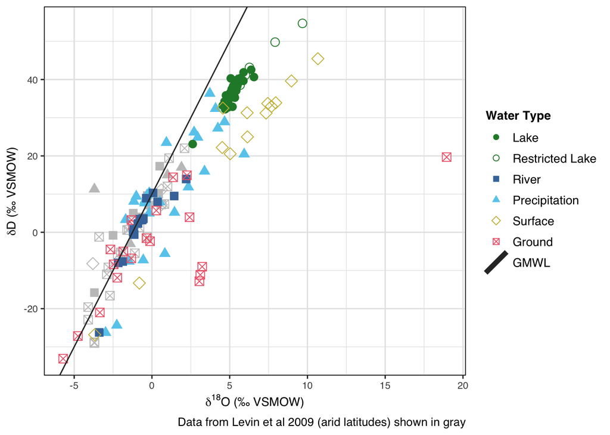

## Figure 3. Time series

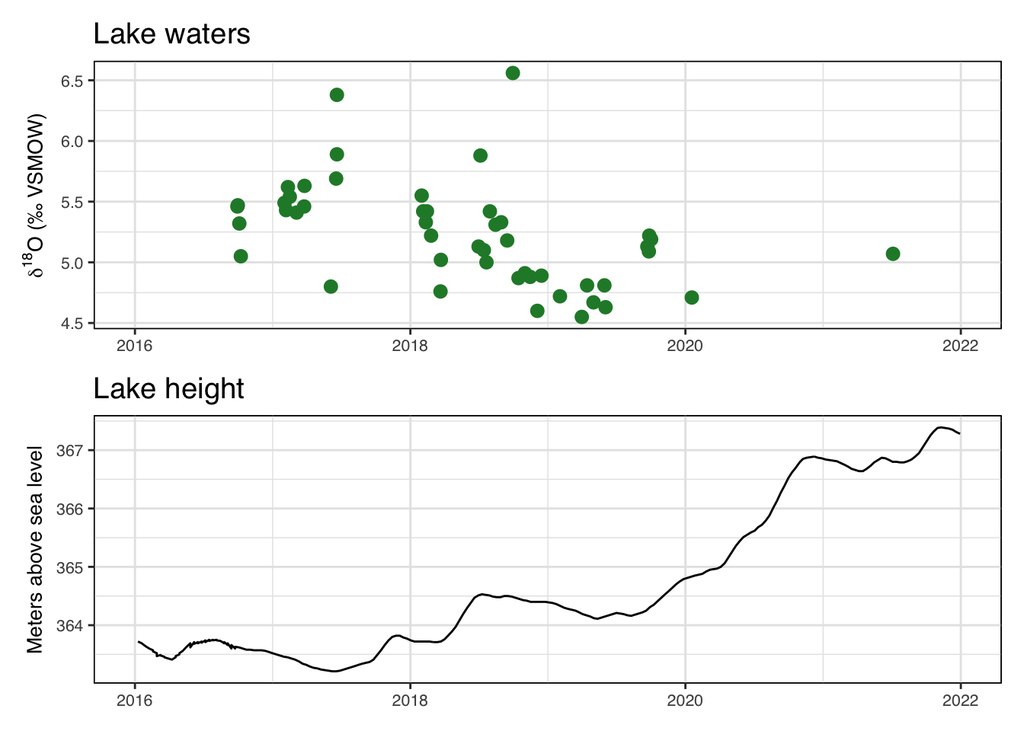

# Local evaporation line model

## Define model function

*Copied to `evaporation-model.R` script for use in interactive / publication version.*

The function produces a plot-able data frame of d18O and dD values representing isotope composition of evaporate water given isotope values of input water and atmospheric conditions. Formulas and relationships are defined in @gibson2016 and @horita1994.

```r
model.LEL <- function(env.input){

  # Celsius to Kelvin conversion
  TK <- env.input["TC"] + 273.15

  # liquid-vapor fractionation factors (Horita & Wesolowski 1994)
  aD <- exp( ((1158.8 * TK^3)/1e12) - ((1620.1 * TK^2)/1e9) + ((794.84 * TK)/1e6) - (161.04/1e3)  + (2.992e6/TK^3) )
  a18O <- exp( (-7.685e-3) + (6.7123 / TK) - (1.6664e3 / TK^2) + (0.35041e6 / TK^3) )

  # equilibrium isotopic separation (ibid.)
  eD <- (aD - 1) * 1000
  e18O <- (a18O - 1) * 1000

  # diffusion controlled fractionation (ibid.)
  ekD <- 12.5 * (1 - env.input["rh"])
  ek18O <- 14.2 * (1 - env.input["rh"])

  # atmospheric isotope ratios (Gibson et al 2016 eqn 18)
  dDA <- (env.input["dDp"] - (env.input["k"] * eD)) /
    (1 + (1e-3 * env.input["k"] * eD))
  d18OA <- (env.input["d18Op"] - (env.input["k"] * e18O)) /
    (1 + (1e-3 * env.input["k"] * e18O))

  # limiting isotope ratios (Gibson et al 2016 eqn 7)
  dstarD <- ((env.input["rh"] * dDA) + ekD + (eD / aD)) /
    (env.input["rh"] - (1e-3 * (ekD + (eD / aD))))
  dstar18O <- ((env.input["rh"] * d18OA) + ek18O + (e18O / a18O)) /
    (env.input["rh"] - (1e-3 * (ek18O + (e18O / a18O))))

  # temporal enrichment slope (Gibson et al 2016 eqn 6)
  mD <- (env.input["rh"] - (1e-3 * (ekD + (eD / aD)))) /
    ((1 - env.input["rh"]) + (1e-3 * ekD))
  m18O <- (env.input["rh"] - (1e-3 * (ek18O + (e18O / a18O)))) /
    ((1 - env.input["rh"]) + (1e-3 * ek18O))

  # create values for evaporation to inflow ratio (x = E / I) from 0 (no evaporation, lake growing) to 1 (fully evaporated lake)
  # adjust "by" param up or down to have fewer or more points on the model line
  x <- seq(from = 0, to = 1, by = 0.07)

  # lake water isotopes for values of x (Gibson et al 2016 eqn 10) and vapor isotopes (eqn 3)
  dDL <- (env.input["dDi"]  + (mD * x * dstarD)) / (1 + mD * x)
  d18OL <- (env.input["d18Oi"] + (m18O * x * dstar18O)) / (1 + m18O * x)
  dDv <- (((dDL - eD) / aD) - (env.input["rh"] * dDA) - ekD) / (1 - env.input["rh"] + (1e-3 * ekD))
  d18Ov <- (((d18OL - e18O) / a18O) - (env.input["rh"] * d18OA) - ek18O) / (1 - env.input["rh"] + (1e-3 * ek18O))

  # combine modeled lake and vapor delta values in data frame for plotting
  dL <- as.data.frame(cbind("d18O" = d18OL, "dD" = dDL))
  dv <- as.data.frame(cbind("d18O" = d18Ov, "dD" = dDv))
  model.line <- as.data.frame(rbind(dL, dv))

  return(model.line)
}
```

## Model inputs

Build model evaporation lines by varying environmental conditions.

```r
# Create model scenarios for each variable
values.TC = c(25, 30, 35, 40)
values.rh = c(0.2, 0.35, 0.5, 0.65)
values.k = c(0.1, 0.3, 0.5, 0.7)

vary.TC = NULL
for (nn in 1:4){
  this.LEL = model.LEL(c(
    "TC" = values.TC[nn],
    "rh" = .25,
    "d18Oi" = -1,
    "dDi" = 5,
    "d18Op" = 0,
    "dDp" = 10,
    "k" = 0.1)) |>
    mutate(Scenario = as.character(values.TC[nn]))
  vary.TC <- rbind(vary.TC, this.LEL)
}

vary.rh = NULL
for (nn in 1:4){
  this.LEL = model.LEL(c(
    "TC" = 30,
    "rh" = values.rh[nn],
    "d18Oi" = -1,
    "dDi" = 5,
    "d18Op" = 0,
    "dDp" = 10,
    "k" = 0.1)) |>
    mutate(Scenario = as.character(values.rh[nn]))
  vary.rh <- rbind(vary.rh, this.LEL)
}

vary.k = NULL
for (nn in 1:4){
  this.LEL = model.LEL(c(
    "TC" = 30,
    "rh" = .25,
    "d18Oi" = -1,
    "dDi" = 5,
    "d18Op" = 0,
    "dDp" = 10,
    "k" = values.k[nn])) |>
    mutate(Scenario = as.character(values.k[nn]))
  vary.k <- rbind(vary.k, this.LEL)
}
```

### Model with meteoric waters

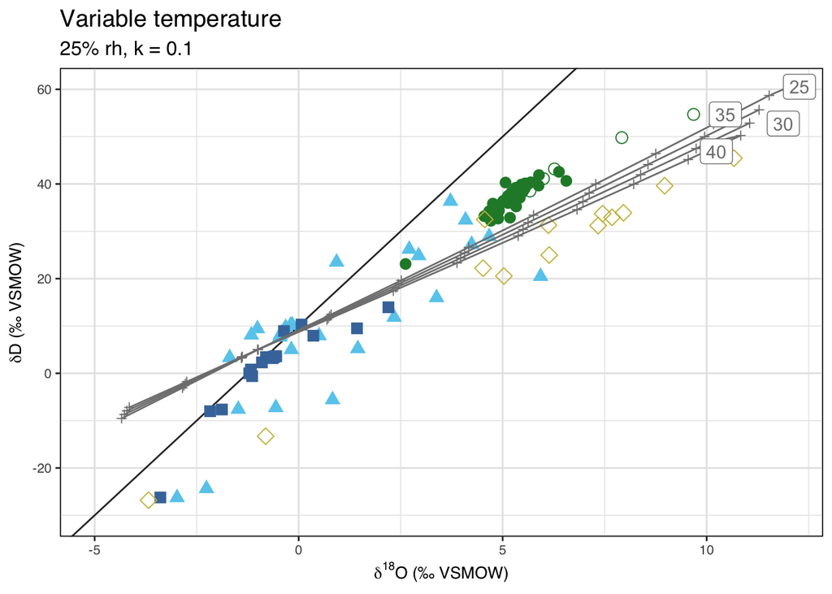

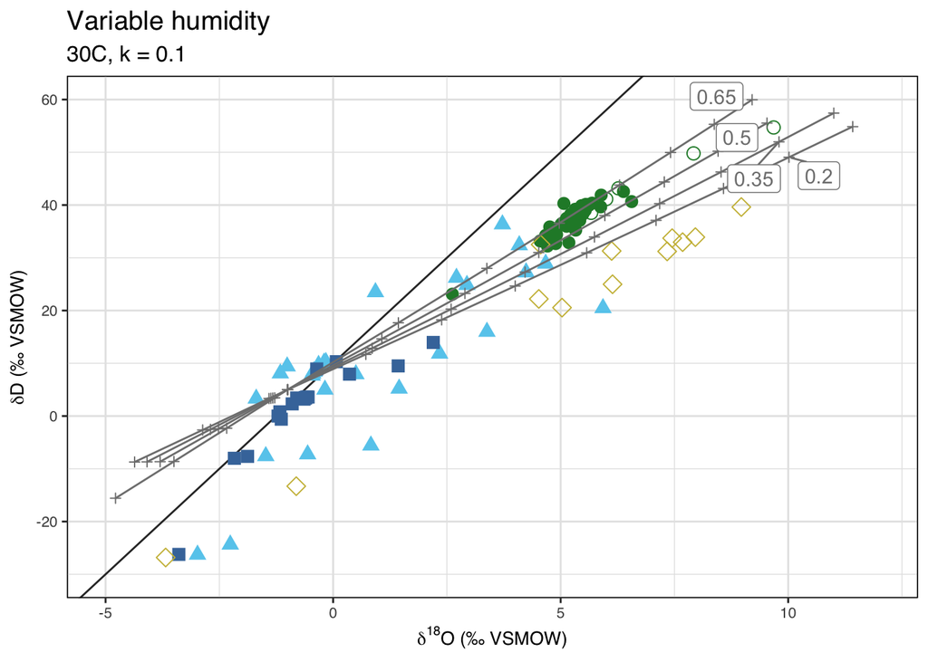

[figure not shown]